# Test a Perceptual Phenomenon

## Analyzing the Stroop Effect

### Background Information:

In a Stroop task, participants are presented with a list of words, with each word displayed in a color of ink. The participant’s task is to say out loud the color of the ink in which the word is printed. The task has two conditions: a congruent words condition, and an incongruent words condition. In the congruent words condition, the words being displayed are color words whose names match the colors in which they are printed: for example RED, BLUE. In the incongruent words condition, the words displayed are color words whose names do not match the colors in which they are printed: for example PURPLE, ORANGE. In each case, we measure the time it takes to name the ink colors in equally-sized lists. Each participant will go through and record a time from each condition.

### Questions For Investigation:

(1) What is the independent variable? What is the dependent variable?

The independent variable is congruent words condition that the words should match with their color or not.

The dependent variable is the time it takes to name the ink colors that the matched with its words or not.

(2) What is an appropriate set of hypotheses for this task? Specify your null and alternative hypotheses, and clearly define any notation used. Justify your choices.

H0 (Null Hypothesis): There is no effect to increase the time when the word doesn't match its color.

$H_{0}$: $M_{i}$ ≤ $M_{c}$

H1 (Alternate Hypothesis): There is an effect to increase the time when the word doesn't match its color.

$H_{1}$: $M_{i}$ > $M_{c}$

$M_{c}$ is the mean of Congruent . $M_{i}$ is the mean of Incongruent .

(3) Report some descriptive statistics regarding this dataset. Include at least one measure of central tendency and at least one measure of variability. The name of the data file is 'stroopdata.csv'.

```python
# Perform the analysis here
import pandas as pd
import numpy as np
import math
import matplotlib.pyplot as plt
%matplotlib inline
```

```python
df = pd.read_csv('stroopdata.csv')
```

```python
df.head(5)
```

|  | Congruent | Incongruent |
| --- | --- | --- |
| 0 | 12.079 | 19.278 |
| 1 | 16.791 | 18.741 |
| 2 | 9.564 | 21.214 |
| 3 | 8.630 | 15.687 |
| 4 | 14.669 | 22.803 |

```python
df.describe()
```

|  | Congruent | Incongruent |
| --- | --- | --- |
| count | 24.000000 | 24.000000 |
| mean | 14.051125 | 22.015917 |
| std | 3.559358 | 4.797057 |
| min | 8.630000 | 15.687000 |
| 25% | 11.895250 | 18.716750 |
| 50% | 14.356500 | 21.017500 |
| 75% | 16.200750 | 24.051500 |
| max | 22.328000 | 35.255000 |

```python
df.info()
```

```
<class 'pandas.core.frame.DataFrame'>
RangeIndex: 24 entries, 0 to 23
Data columns (total 2 columns):
Congruent      24 non-null float64
Incongruent    24 non-null float64
dtypes: float64(2)
memory usage: 464.0 bytes
```

(4) Provide one or two visualizations that show the distribution of the sample data. Write one or two sentences noting what you observe about the plot or plots.

```
Text(0.5,0,'Congruent time')
```

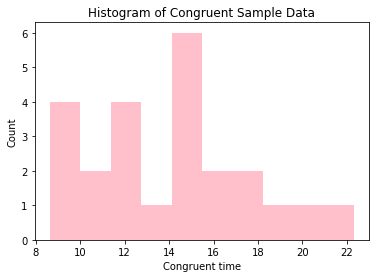

```python
# Build the visualizations here

num_bins = 10
plt.hist(df['Congruent'], num_bins, color='pink')
plt.title("Histogram of Congruent Sample Data")
plt.ylabel("Count")
plt.xlabel("Congruent time")
```

```
Text(0.5,0,'Incongruent time')
```

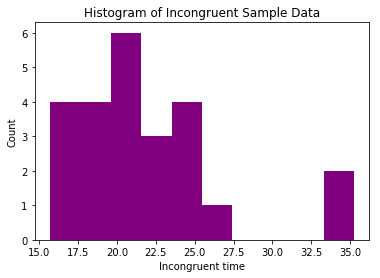

```python
num_bins = 10
plt.hist(df['Incongruent'], num_bins, color='purple')
plt.title("Histogram of Incongruent Sample Data")
plt.ylabel("Count")
plt.xlabel("Incongruent time")
```

(5) Now, perform the statistical test and report your results. What is your confidence level or Type I error associated with your test? What is your conclusion regarding the hypotheses you set up? Did the results match up with your expectations? **Hint:** Think about what is being measured on each individual, and what statistic best captures how an individual reacts in each environment.

The difference of the means is: 22.02 - 14.05 = 7.97

```python
#calculate standard deviation of differences
df['Difference']= df['Congruent'] - df['Incongruent']
df['Difference'].std(axis=0)
```

```
4.8648269103590556
```

```python
#calculate standard error of differences
stdev_diff= (4.86/math.sqrt(24))
print(stdev_diff)
```

```
0.9920433458271872
```

```python
#calculate t-statistic
t_statistic= (7.97/stdev_diff)
print(t_statistic)
```

```
8.03392314814071
```

Degrees of freedom (n-1)

df = 23

The P-Value is < .00001

Results: Since the p-value is less than 0.05, we will reject the null hypothesis.

References: To find p-vale https://www.socscistatistics.com/pvalues/tdistribution.aspx https://www.statisticshowto.datasciencecentral.com/probability-and-statistics/